# CA CODE and GHE CSMF Comparison

# Summary

- Regional fractions are relatively similar overall
- Higher HIV from 2000-2015 for GHE
- Higher malaria for CA CODE for 5-9y and 10-14y
- Higher maternal for GHE
- Higher CollectVio for GHE
  - A small share of global deaths in all ages except 15-19m
- Large uncertainty in OtherCMPN and OtherNCD for both CA CODE and GHE
- Non-trivial COVID19 in 2021 for GHE
  - 4-5.5% of global deaths for 10-14y, 15-19y
  - 10-12% of South-East Asia deaths for 5-9y, 10-14y, 15-19y

# 5-9y

## All causes

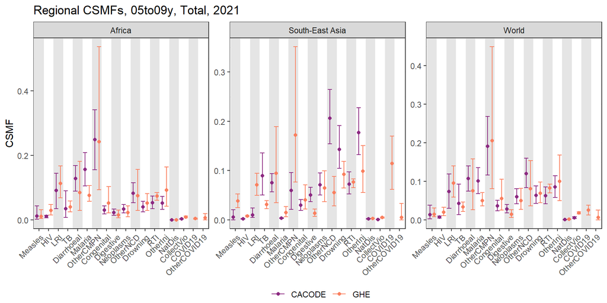

- World fractions relatively similar
- In Africa, mostly overlapping uncertainty bounds
  - Higher malaria for CA CODE
  - Higher OtherInj for GHE
- In South-East Asia, GHE OtherCMPN higher and OtherNCD lower than CA CODE
  - COVID19 10.8% in GHE

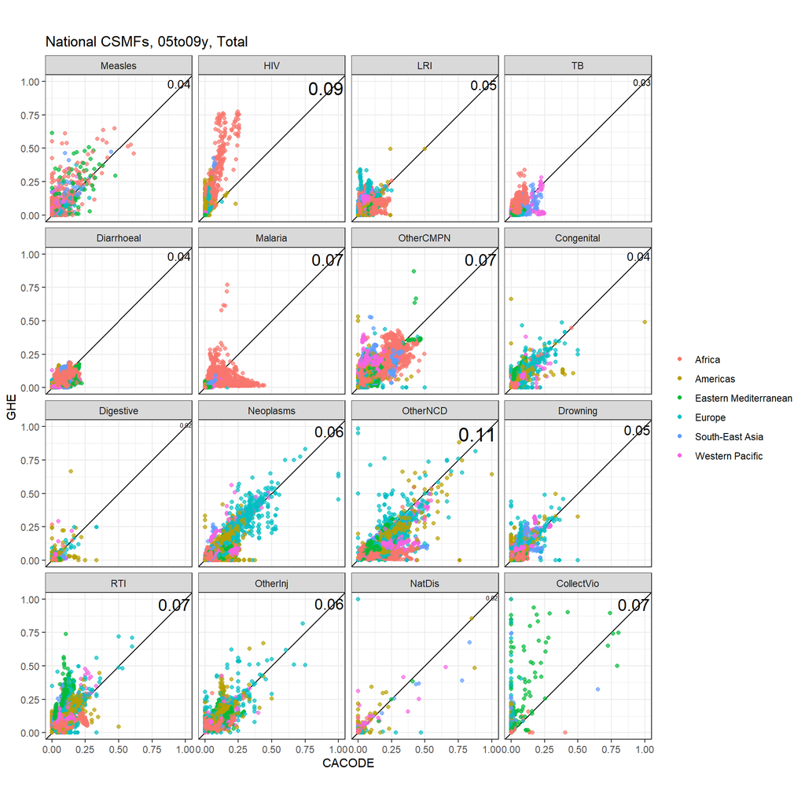

- Highest RMSE for OtherNCD, HIV
- GHE has higher HIV
- Large spread in OtherNCD

## HIV

Countries with largest average difference in HIV.

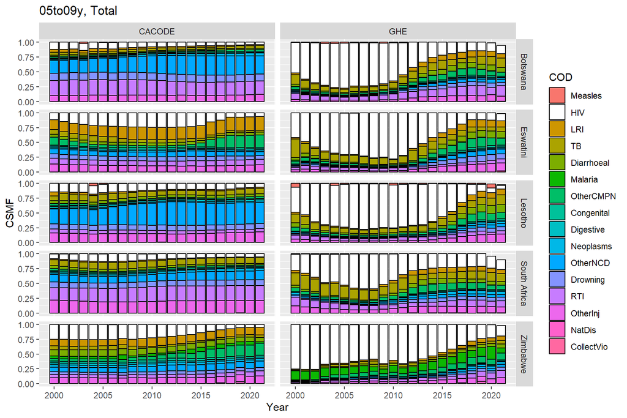

## Malaria

Countries with largest average difference in malaria.

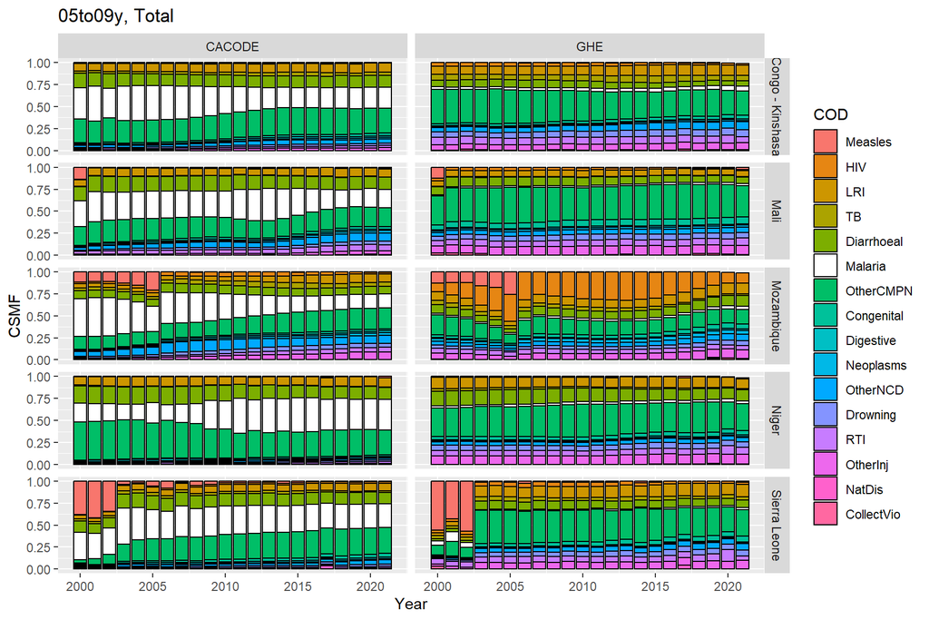

## OtherNCD

High burden countries (top 50% in total deaths in 2010) with largest differences in OtherNCD.

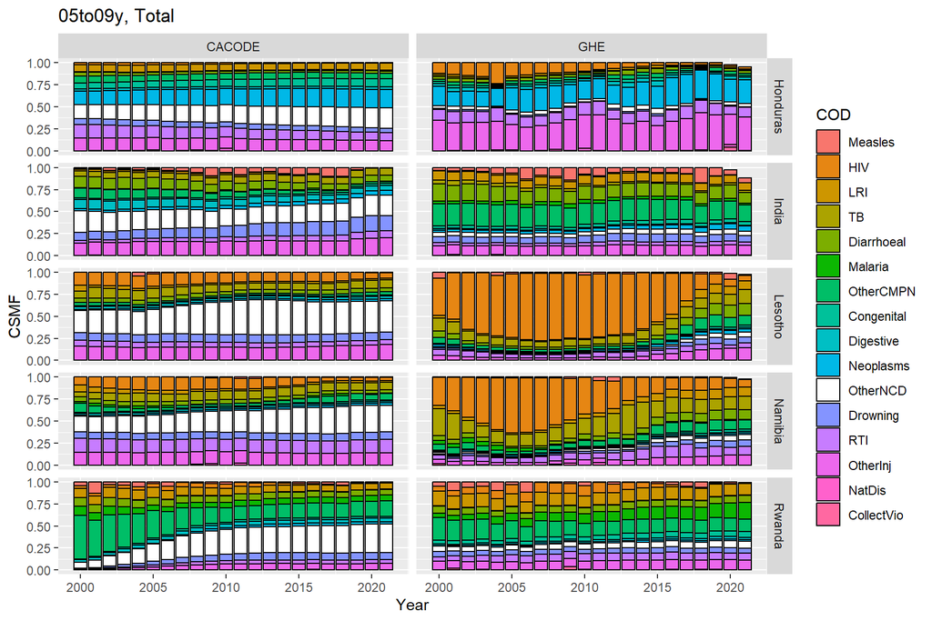

# 10-14y

## All causes

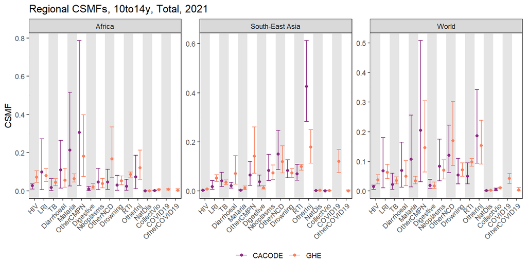

- In Africa, higher malaria and OtherCMPN for CA CODE
  - Higher OtherNCD for GHE
- In South-East Asia, higher OtherInj for CA CODE

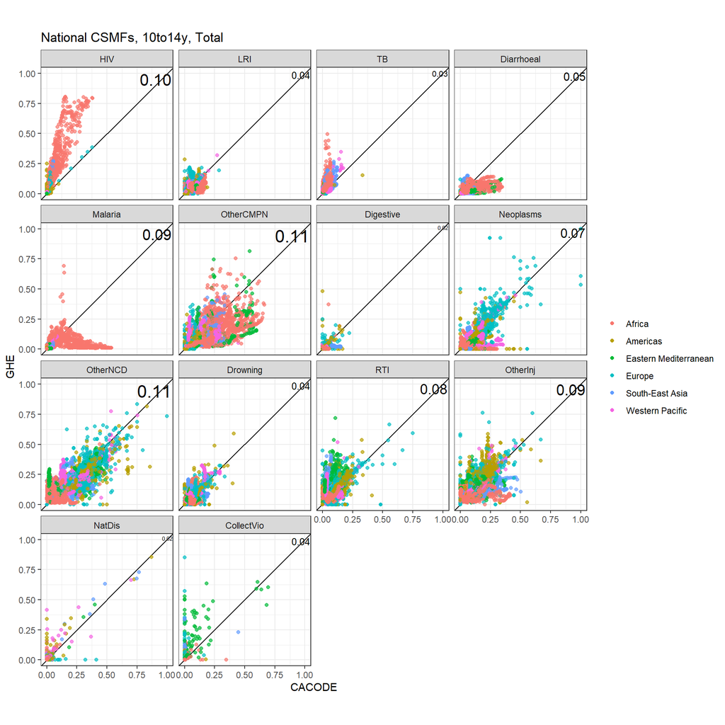

- Highest RMSE for OtherCMPN, OtherNCD, HIV
- GHE has higher HIV
- CA CODE has higher malaria

## HIV

Countries with largest average difference in HIV.

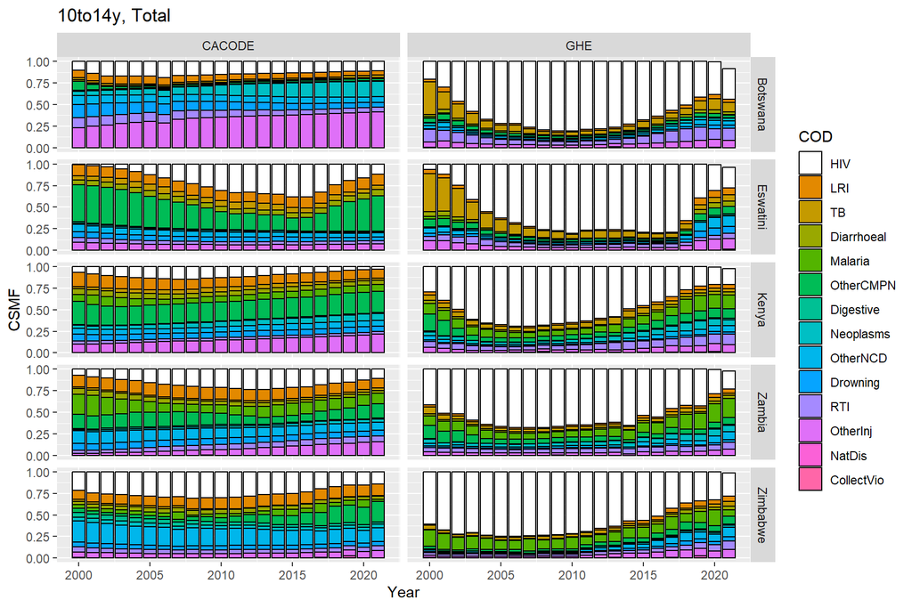

## Malaria

Countries with largest average difference in malaria.

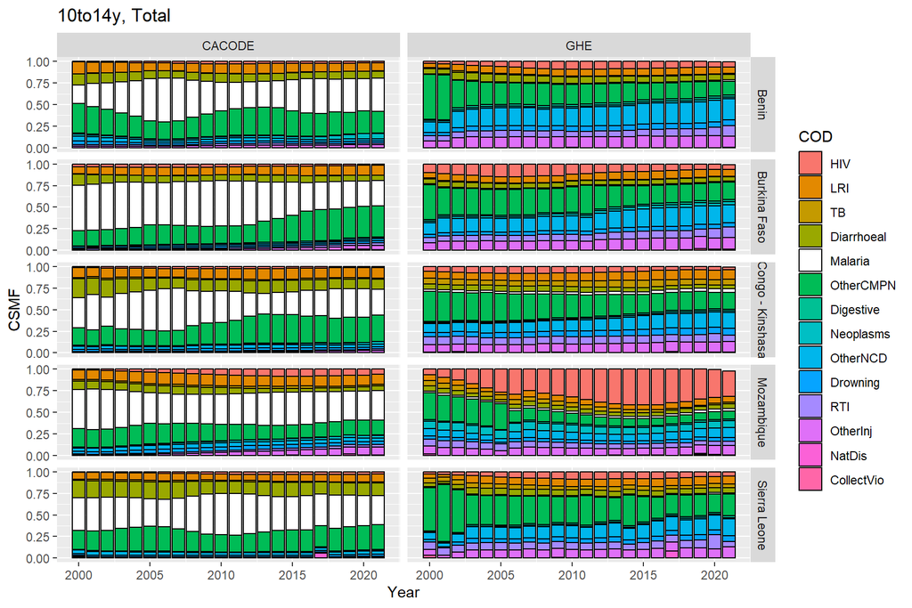

# 15-19y F

## All causes

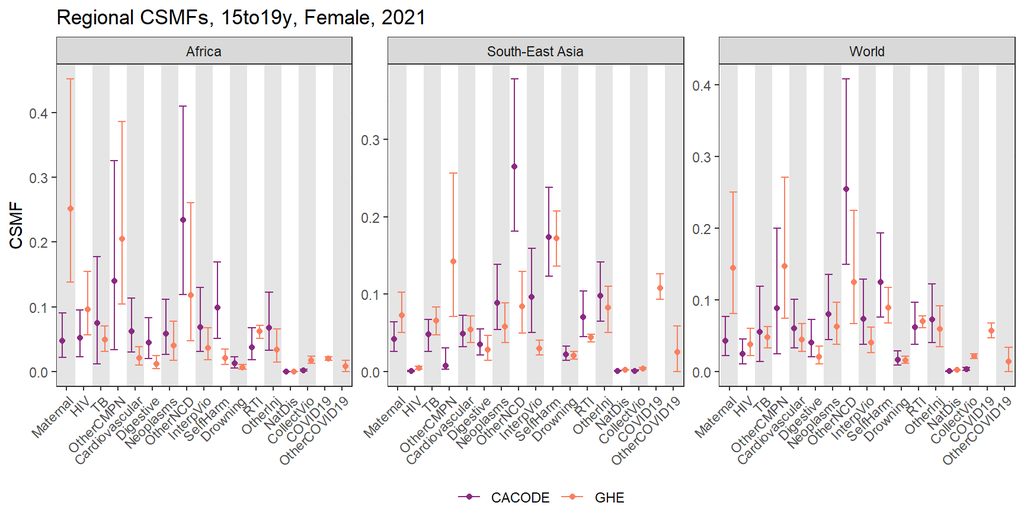

- In world, higher maternal for GHE
  - Higher OtherNCD for CA CODE
- In Africa, higher maternal for GHE
  - Higher OtherNCD, SelfHarm for CA CODE
- In South-East Asia, higher OtherCMPN, COVID19 for GHE
  - Higher OtherNCD, InterpVio for CA CODE

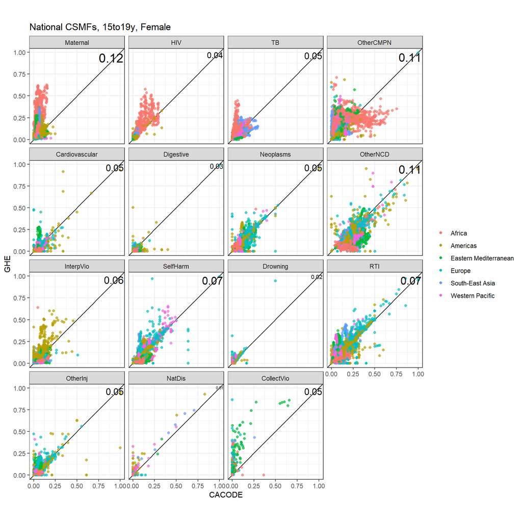

- Highest RMSE for maternal, OtherCMPN, OtherNCD

## Maternal

Countries with largest average difference in maternal.

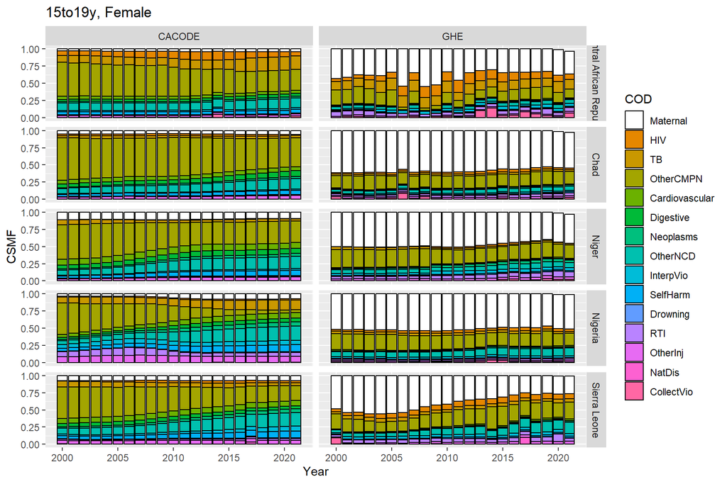

# 15-19y M

## All causes

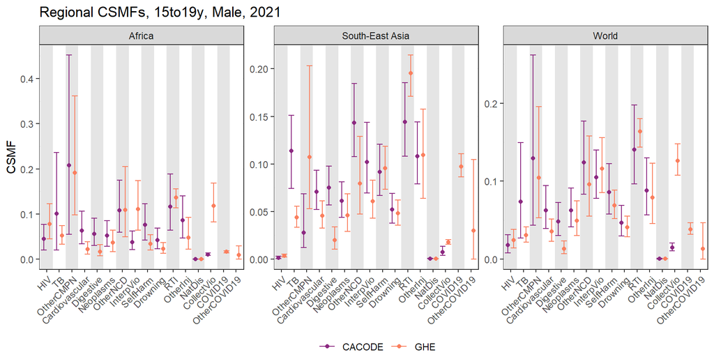

- In world, higher TB for CA CODE
  - Higher CollectVio for GHE
- In Africa, higher CollectVio for GHE
- In South-East Asia, higher TB, digestive, OtherNCD, InterpVio for CA CODE
  - High COVID19 for GHE

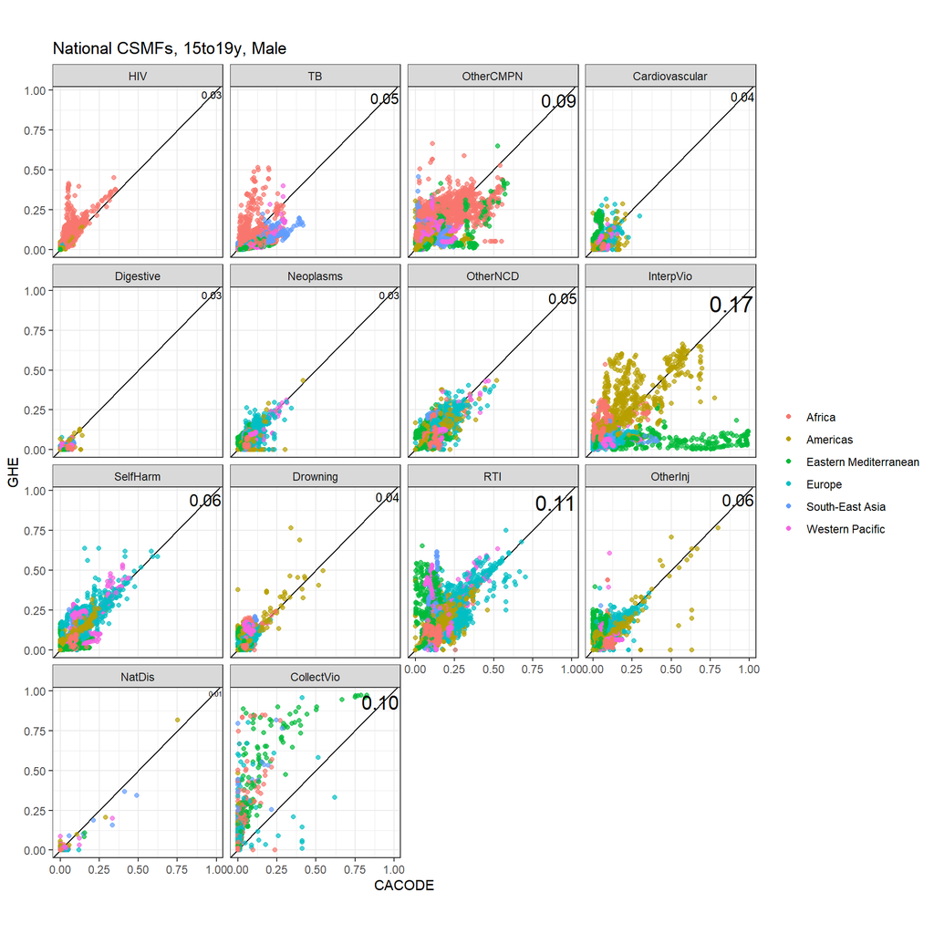

- Highest RMSE for InterpVio
  - CA CODE has much higher InterpVio in Eastern Mediterranean
- GHE has higher CollectVio

## CollectVio

High burden countries (top 50% in total deaths in 2010) with largest differences in CollectVio.

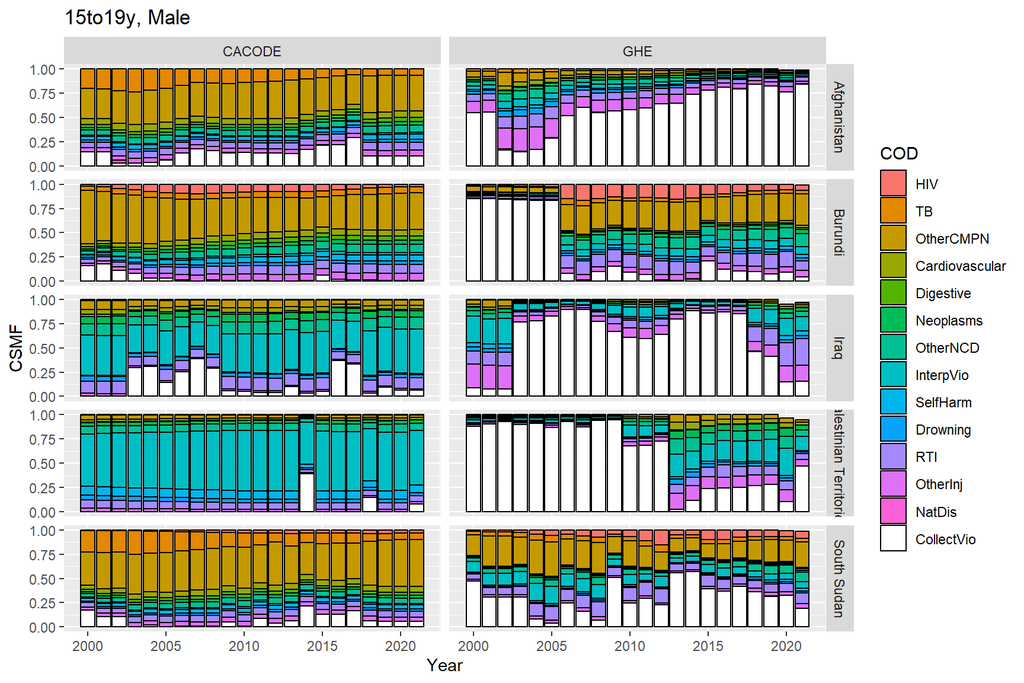

## InterpVio

Countries with largest average difference in InterpVio.

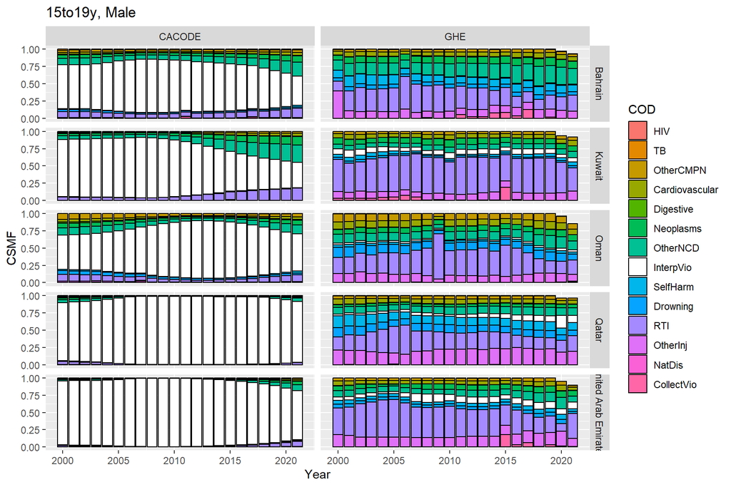

InterpVio in Americas.

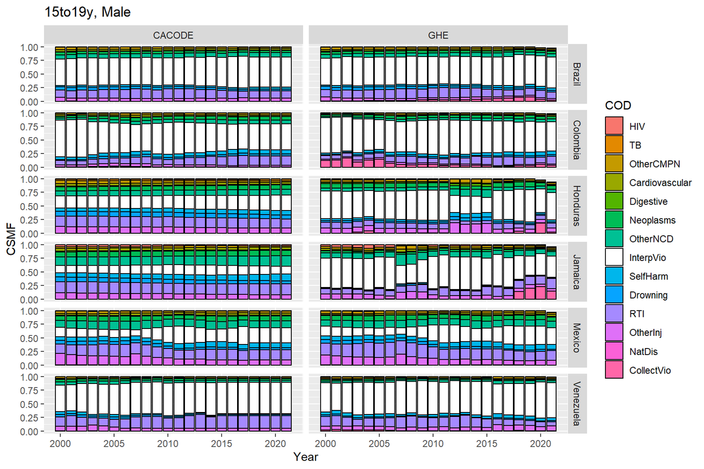

# CA CODE methods

## 5-9y

| COD | Split | Method | Details | Source |  |  |
| --- | --- | --- | --- | --- | --- | --- |
| CollectVio, NatDis | Endemic | Squeezed pro-rata into crisis-free deaths | Add endemic ColVio and NatDis to crisis-free deaths. Calculate fractions. Squeeze other causes into remaining fraction. |  |  |  |
|  | Epidemic | Distributed to difference between crisis-free and crisis-included envelopes | Calculate proportion of epidemic deaths that are ColVio versus NatDis. Multiply proportion of colvio/natdis deaths by difference between all-cause and crisis-free envelopes. |  |  |  |
| Congenital |  | Modeled |  |  |  |  |
| Diarrhoeal |  | Modeled |  |  |  |  |
| Digestive |  | Modeled |  |  |  |  |
| Drowning |  | Modeled |  |  |  |  |
| HIV |  | Squeezed into OtherCMPN | Multiply OtherCMPN fraction by crisis-free deaths. Subtract single-cause (i.e., HIV, measles, TB) deaths from OtherCMPN and calculate residual OtherCMPN fraction. If residual OtherCMPN is less than mi… |  | UNAIDS |  |
| LRI |  | Modeled |  |  |  |  |
| Malaria | HMM | Modeled and capped at country-year level for 1-59m | If malaria case count for 5-19y is zero, set fraction as zero and re-calculate other fractions pro-rata. |  | WMP for case count |  |
|  | LMM | Set as zero |  |  |  |  |
| Measles | Endemic | Squeezed into OtherCMPN | Multiply OtherCMPN fraction by crisis-free deaths. Subtract single-cause (i.e., HIV, measles, TB) deaths from OtherCMPN and calculate residual OtherCMPN fraction. If residual OtherCMPN is less than mi… |  | WHO Immunization, Vaccinations and Biologicals Programme |  |
|  | Epidemic | Added to crisis-included deaths | Back-calculate denominator of all-cause crisis-included mortality rate, add epidemic measles deaths, recalculate all-cause crisis-included rate. |  |  |  |
| Neoplasms |  | Modeled |  |  |  |  |
| OtherCMPN |  | Modeled |  |  |  |  |
| OtherNCD |  | Modeled |  |  |  |  |
| OtherInj |  | Modeled |  |  |  |  |
| TB | Non-respiratory | Squeezed into OtherCMPN | Multiply OtherCMPN fraction by crisis-free deaths. Subtract single-cause (i.e., HIV, measles, TB) deaths from OtherCMPN and calculate residual OtherCMPN fraction. If residual OtherCMPN is less than mi… |  |  | WHO Immunization, Vaccinations and Biologicals Programme |
|  | Respiratory | Squeezed into LRI | Multiply LRI fraction by crisis-free deaths. Subtract respiratory TB deaths from LRI, and calculate residual LRI fraction. If residual LRI is less than minimum allowed fraction (0.0269), calculate sca… |  |  |  |
| RTI |  | Modeled |  |  |  |  |

## 10-14y

| COD | Split | Method | Details | Source |  |  |
| --- | --- | --- | --- | --- | --- | --- |
| CollectVio, NatDis | Endemic | Squeezed pro-rata into crisis-free deaths | Add endemic ColVio and NatDis to crisis-free deaths. Calculate fractions. Squeeze other causes into remaining fraction. |  |  |  |
|  | Epidemic | Distributed to difference between crisis-free and crisis-included envelopes | Calculate proportion of epidemic deaths that are ColVio versus NatDis. Multiply proportion of colvio/natdis deaths by difference between all-cause and crisis-free envelopes. |  |  |  |
| Diarrhoeal |  | Modeled |  |  |  |  |
| Digestive |  | Modeled |  |  |  |  |
| Drowning |  | Modeled |  |  |  |  |
| HIV |  | Squeezed into OtherCMPN | Multiply OtherCMPN fraction by crisis-free deaths. Subtract single-cause (i.e., HIV, TB) deaths from OtherCMPN and calculate residual OtherCMPN fraction. If residual OtherCMPN is less than minimum all… |  | UNAIDS |  |
| LRI |  | Modeled |  |  |  |  |
| Malaria | HMM | Modeled and capped at country-year level for 1-59m | If malaria case count for 5-19y is zero, set fraction as zero and re-calculate other fractions pro-rata. |  | WMP for case count |  |
|  | LMM | Set as zero |  |  |  |  |
| Neoplasms |  | Modeled |  |  |  |  |
| OtherCMPN |  | Modeled |  |  |  |  |
| OtherNCD |  | Modeled |  |  |  |  |
| OtherInj |  | Modeled |  |  |  |  |
| TB | Non-respiratory | Squeezed into OtherCMPN | Multiply OtherCMPN fraction by crisis-free deaths. Subtract single-cause (i.e., HIV, TB) deaths from OtherCMPN and calculate residual OtherCMPN fraction. If residual OtherCMPN is less than minimum all… | WHO Immunization, Vaccinations and Biologicals Programme |  |  |
|  | Respiratory | Squeezed into LRI | Multiply LRI fraction by crisis-free deaths. Subtract respiratory TB deaths from LRI, and calculate residual LRI fraction. If residual LRI is less than minimum allowed fraction (0.0197), calculate sca… |  |  |  |
| RTI |  | Modeled |  |  |  |  |

## 15-19y

| COD | Split | Method | Details | Source |  |  |  |
| --- | --- | --- | --- | --- | --- | --- | --- |
| Cardiovascular |  | Modeled |  |  |  |  |  |
| CollectVio, NatDis | Endemic | Squeezed pro-rata into crisis-free deaths | Add endemic ColVio and NatDis to crisis-free deaths. Calculate fractions. Squeeze other causes into remaining fraction. |  |  |  |  |
|  | Epidemic | Distributed to difference between crisis-free and crisis-included envelopes | Calculate proportion of epidemic deaths that are ColVio versus NatDis. Multiply proportion of colvio/natdis deaths by difference between all-cause and crisis-free envelopes. |  |  |  |  |
| Digestive |  | Modeled |  |  |  |  |  |
| Drowning |  | Modeled |  |  |  |  |  |
| HIV |  | Squeezed into OtherCMPN | Multiply OtherCMPN fraction by crisis-free deaths. Subtract single-cause (i.e., HIV, TB) deaths from OtherCMPN and calculate residual OtherCMPN fraction. If residual OtherCMPN is less than minimum all… |  | UNAIDS |  |  |
| InterpVio |  | Modeled |  |  |  |  |  |
| Maternal | Females | Modeled |  |  |  |  |  |
| Neoplasms |  | Modeled |  |  |  |  |  |
| OtherCMPN |  | Modeled |  |  |  |  |  |
| OtherNCD |  | Modeled |  |  |  |  |  |
| OtherInj |  | Modeled |  |  |  |  |  |
| TB | Non-respiratory | Squeezed into OtherCMPN | Multiply OtherCMPN fraction by crisis-free deaths. Subtract single-cause (i.e., HIV, TB) deaths from OtherCMPN and calculate residual OtherCMPN fraction. If residual OtherCMPN is less than minimum all… |  |  | WHO Immunization, Vaccinations and Biologicals Programme |  |
|  | Respiratory | Squeezed into LRI | Multiply LRI fraction by crisis-free deaths. Subtract respiratory TB deaths from LRI, and calculate residual LRI fraction. If residual LRI is less than minimum allowed fraction (0.0197), calculate sca… |  |  |  |  |
| RTI |  | Modeled |  |  |  |  |  |